## **Taller:** Regularización

# Algoritmos de Machine Learning

Marcelo Chávez  
Machine Learning con Python

# **Regularización**

La **regularización** es una técnica utilizada en modelos estadísticos y de aprendizaje automático para prevenir el sobreajuste, añadiendo una penalización a la magnitud de los coeficientes del modelo. Su objetivo es mejorar la generalización del modelo sobre datos no vistos.

Matemáticamente, la regularización se implementa agregando un término de penalización a la función de pérdida. En el caso de la regresión lineal, se expresa como:

$$ \min_{\boldsymbol{\beta}} \sum_{i=1}^{n} \left( y_i - \boldsymbol{x}_i^\top \boldsymbol{\beta} \right)^2 + \lambda R(\boldsymbol{\beta}) $$

donde:

- $\lambda$ es el parámetro de regularización que controla la penalización.
- $R(\boldsymbol{\beta})$ es la función de regularización, que puede ser:
  - **Lasso (L1)**: $R(\boldsymbol{\beta}) = \sum_{j} |\beta_j|$, que induce modelos más esparcidos.
  - **Ridge (L2)**: $R(\boldsymbol{\beta}) = \sum_{j} \beta_j^2$, que reduce la varianza sin forzar coeficientes a cero.
  - **Elastic Net**: combinación de L1 y L2.

**Fuente:** Hastie, T., Tibshirani, R., & Friedman, J. (2009). *The Elements of Statistical Learning*. Springer.

# **Objetivos**

- Resolver problemas mal planteados (ill-posed-problems)
- Obtener soluciones esparcidas (soluciones con muchos ceros)

$$ Y_i = \beta_0 + \beta_1 X_1 + \beta_2 X_2 + \dots + \beta_{100} X_{100} + \varepsilon_i $$

Sea el vector de coeficientes:

$$ \boldsymbol{\beta} = \begin{bmatrix} 1, & 0.5, & 0, & 0, & 0, & 0, & 0, & 0, & 0, & 6, & 8, & 9, & \dots, & 0, & 5 \end{bmatrix} $$

Donde la mayoría de los valores son ceros, y algunos coeficientes con valores $\neq 0$ dispersos en el vector.

## **Resolver problemas mal planteados**

- Problemas al invertir $X^{T}X$:

Gauss propuso la siguiente solucion: $\hat{\beta}=(X^{T}X)^{-1}X^{T}y$

$$ \begin{bmatrix} y_1 \\ y_2 \\ \vdots \\ y_n \end{bmatrix} = \begin{bmatrix} 1 & x_{1,1} & x_{1,2} & \dots & x_{1,p} \\ 1 & x_{2,1} & x_{2,2} & \dots & x_{2,p} \\ \vdots & \vdots & \vdots & \ddots & \vdots \\ 1 & x_{n,1} & x_{n,2} & \dots & x_{n,p} \end{bmatrix} \begin{bmatrix} \beta_0 \\ \beta_1 \\ \vdots \\ \beta_p \end{bmatrix} + \begin{bmatrix} \varepsilon_1 \\ \varepsilon_2 \\ \vdots \\ \varepsilon_n \end{bmatrix} $$

- Reducir la multicolinealidad:

# 📌 Multicolinealidad en Regresión Lineal

## 🔹 ¿Qué es la Multicolinealidad?

La **multicolinealidad** ocurre cuando dos o más variables predictoras en un modelo de regresión están altamente correlacionadas, lo que dificulta estimar con precisión los coeficientes del modelo.

Cuando esto sucede, el modelo puede volverse inestable y los coeficientes pueden cambiar drásticamente con pequeños cambios en los datos.

## 🔹 Tipos de Multicolinealidad

Existen dos tipos principales:

1. **Multicolinealidad Perfecta**:
   - Ocurre cuando una variable predictora es una combinación exacta de otras variables.
   - Ejemplo: Si $X_3 = 2X_1 + 3X_2$, entonces hay colinealidad perfecta.
2. **Multicolinealidad Imperfecta**:
   - Ocurre cuando las variables están altamente correlacionadas, pero no son combinaciones exactas entre sí.

## 🔹 Problemas que Causa la Multicolinealidad

✅ Dificultad para interpretar los coeficientes $\beta$.  
✅ Aumento en la varianza de los estimadores.  
✅ Signos y magnitudes inestables en los coeficientes.  
✅ El **estadístico $t$** puede no ser significativo aunque el modelo tenga un buen ajuste $R^2$.

Matemáticamente, la varianza de los coeficientes en regresión lineal se expresa como:

$$ \text{Var}(\hat{\beta}) = \sigma^2 (\mathbf{X}^T \mathbf{X})^{-1} $$

Si $\mathbf{X}^T \mathbf{X}$ es **casi singular** (es decir, tiene valores propios cercanos a 0), la varianza de los coeficientes será muy grande, lo que indica problemas de multicolinealidad.

## 🔹 ¿Cómo Detectarla?

Algunas formas comunes de detectar multicolinealidad incluyen:

1. **Matriz de correlación**: Si las variables tienen coeficientes de correlación altos $(> 0.8)$, puede haber colinealidad.
2. **Factor de Inflación de la Varianza (VIF)**:

   $$ VIF(\beta_j) = \frac{1}{1 - R_j^2} $$

   Si $VIF > 10$, hay un problema grave de multicolinealidad.

## 🔹 ¿Cómo Solucionarla?

🔸 **Eliminar variables altamente correlacionadas**.  
🔸 **Realizar una transformación (PCA, Regresión Ridge|Lasso)**.  
🔸 **Obtener más datos** (si es posible).  
🔸 **Combinar variables correlacionadas en una sola variable representativa**.

**Conclusión**: La multicolinealidad no siempre es un problema si el objetivo del modelo es la predicción. Sin embargo, si se busca interpretar los coeficientes, es crucial identificar y corregir la colinealidad para obtener estimaciones confiables.

📌 *Referencias:*

- James, G., Witten, D., Hastie, T., & Tibshirani, R. (2013). *An Introduction to Statistical Learning*.
- Montgomery, D. C., Peck, E. A., & Vining, G. G. (2012). *Introduction to Linear Regression Analysis*.

## **Regresión LASSO y Ridge**

- Su finalidad es encontrar estimadores para los coeficientes de la regresión lineal $\beta$ con un riesgo menor que el de mínimos cuadrados.
- Dos grandes ventajas frente a métodos heurísticos (como stepwise) sus soluciones son más rápidas y tienen mayores garantías teóricas.
- El estimador para la regresión lasso minimiza la suma del error cuadrático medio más una medida de complejidad del vector $\beta$

### **Como medir la complejidad de $\beta$**

Una alternativa es contar el número de variables que están siendo usadas en el modelo, es decir: $$p = \sum_{i=1}^{d}\Pi(\beta_{i}\neq 0)$$

- Siendo $p$ el número de variables utilizadas por el modelo.
- El número de $\beta_{i}$ que son diferentes de 0.
- Esto es conocido como la **norma 0** del vector, denotado por: $\left\|\beta\right\|_{L_{0}}$

### **Norma $L_{1}$**

Sin duda, no es lo mismo un $\hat{\beta}_{r}=0.1$ que $\hat{\beta}_{r}=100$, por lo tanto podemos usar otros tipos de normas. La regresión LASSO se basa justamente en la norma $L_{1}$ dads por $$\|\beta\|_{L_1} = \sum_{i=1}^{d} |\beta_i|$$

### **Norma $L_{2}$** *(la norma más usada en ML)*

En cambio, la regresión *Ridge* se basa en la normal $L_{2}$ dada por:

$$\|\beta\|_{L_2} = \sum_{i=1}^{d} \beta^2_i$$

#### **Medidas de esparsidad y/o penalización**

| Valores de $\beta$ | Valores de $\sum_{j=1}^{d} I (\beta_j \neq 0)$ | Penalización Lasso $L_{1} = \sum_{j=1}^{d} |\beta_j|$ | Penalización Ridge $L_{2} = \sum_{j=1}^{d} \beta_j^2$ | |:-----------------------------------------------:|:-----------------------------------------------------------:|:--------------------------------------------------------:|:--------------------------------------------------------:| | $(0, 0, 0, 0, 0, 0, 0, 0, 0, 0)$ | 0 | 0 | 0.0 | | $(0.1, 0.1, 0.1, 0.1, 0.1, 0.1, 0.1, 0.1, 0.1, 0.1)$ | 10 | 1 | 0.1 | | $(1, 1, 1, 1, 1, 1, 1, 1, 1, 1)$ | 10 | 10 | 10.0 |

$L_{1}$ penaliza más fuertemente a los valores cercanos a 0

A mayor la norma, mayor el número de betas alejados del cero

## **Modelo Lasso**

Formalmente, la solución está dada por:

El modelo Lasso se define como:

$$ \hat{\beta}_{L_{1}} = \underset{\beta \in \mathbb{R}^d}{\text{argmin}} \sum_{i=1}^{n} (y_i - \hat{y}_i)^2 + \lambda \|\beta\|_{L_1} $$

donde:

- $ \hat{\beta} $ son los coeficientes estimados,
- $ y_i $ es la variable dependiente,
- $ \hat{y}_i $ son las predicciones del modelo,
- $ \lambda $ es el parámetro de penalización,
- $ \beta_j $ son los coeficientes del modelo.

```
        age       sex       bmi        bp        s1        s2        s3  \
0  0.038076  0.050680  0.061696  0.021872 -0.044223 -0.034821 -0.043401
1 -0.001882 -0.044642 -0.051474 -0.026328 -0.008449 -0.019163  0.074412
2  0.085299  0.050680  0.044451 -0.005670 -0.045599 -0.034194 -0.032356
3 -0.089063 -0.044642 -0.011595 -0.036656  0.012191  0.024991 -0.036038
4  0.005383 -0.044642 -0.036385  0.021872  0.003935  0.015596  0.008142

         s4        s5        s6  target
0 -0.002592  0.019907 -0.017646   151.0
1 -0.039493 -0.068332 -0.092204    75.0
2 -0.002592  0.002861 -0.025930   141.0
3  0.034309  0.022688 -0.009362   206.0
4 -0.002592 -0.031988 -0.046641   135.0
RMSE Ridge (L2): 53.78
RMSE Lasso (L1): 53.71
```

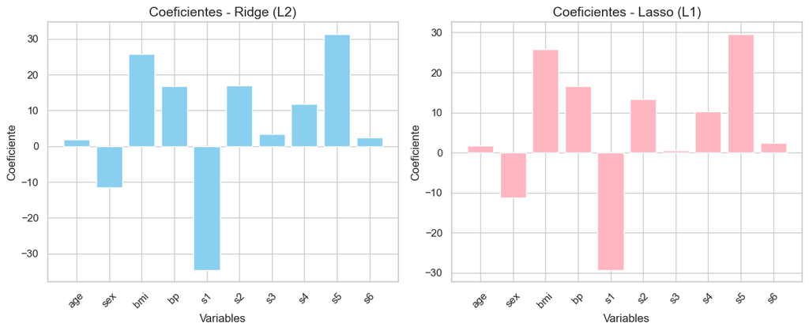

```python
# Importar librerías necesarias
import numpy as np
import matplotlib.pyplot as plt
import seaborn as sns
import pandas as pd
from sklearn.linear_model import Ridge, Lasso
from sklearn.datasets import load_diabetes
from sklearn.model_selection import train_test_split
from sklearn.preprocessing import StandardScaler
from sklearn.metrics import mean_squared_error

# Establecer estilo de gráficos con Seaborn
sns.set(style="whitegrid")

# 1. Cargar el dataset de Diabetes
diabetes = load_diabetes()
X, y = diabetes.data, diabetes.target  # Variables predictoras y objetivo

# 2. Convertir a DataFrame para mejor visualización
df = pd.DataFrame(X, columns=diabetes.feature_names)
df["target"] = y

# Mostrar las primeras filas del dataset
print(df.head())

# 3. Dividir en conjuntos de entrenamiento y prueba (80% - 20%)
X_train, X_test, y_train, y_test = train_test_split(X, y, test_size=0.2, random_state=42)

# 4. Estandarizar los datos para mejorar la estabilidad numérica
scaler = StandardScaler()
X_train_scaled = scaler.fit_transform(X_train)
X_test_scaled = scaler.transform(X_test)

# 5. Ajustar modelos Ridge (L2) y Lasso (L1)
ridge = Ridge(alpha=1.0)  # Regularización L2
lasso = Lasso(alpha=0.1)  # Regularización L1

ridge.fit(X_train_scaled, y_train)
lasso.fit(X_train_scaled, y_train)

# 6. Evaluar los modelos con RMSE (Root Mean Squared Error)
y_pred_ridge = ridge.predict(X_test_scaled)
y_pred_lasso = lasso.predict(X_test_scaled)

rmse_ridge = np.sqrt(mean_squared_error(y_test, y_pred_ridge))
rmse_lasso = np.sqrt(mean_squared_error(y_test, y_pred_lasso))

print(f"RMSE Ridge (L2): {rmse_ridge:.2f}")
print(f"RMSE Lasso (L1): {rmse_lasso:.2f}")

# 7. Graficar los coeficientes de Ridge y Lasso con colores pastel
plt.figure(figsize=(12, 5))

# Colores pastel personalizados
ridge_color = "#89CFF0"  # Azul pastel
lasso_color = "#FFB6C1"  # Rosa pastel

plt.subplot(1, 2, 1)
plt.bar(diabetes.feature_names, ridge.coef_, color=ridge_color)
plt.xticks(rotation=45)
plt.title("Coeficientes - Ridge (L2)", fontsize=14)
plt.xlabel("Variables", fontsize=12)
plt.ylabel("Coeficiente", fontsize=12)

plt.subplot(1, 2, 2)
plt.bar(diabetes.feature_names, lasso.coef_, color=lasso_color)
plt.xticks(rotation=45)
plt.title("Coeficientes - Lasso (L1)", fontsize=14)
plt.xlabel("Variables", fontsize=12)
plt.ylabel("Coeficiente", fontsize=12)

plt.tight_layout()
plt.show()
```

$$ \mathcal{L}(\beta) = \sum_{i=1}^{n} \left( y_i - \hat{y}_i \right)^2 + \lambda \sum_{j=1}^{d} \beta_j^2 $$